# ACTOR: A latent dirichlet model to Compare expressed isoform proportions TO a Reference panel

Sean D. McCabe, Andrew Nobel, and Michael I. Love

02/21/2020

Abstract

*actor* compares expressed isoform proportions to a reference panel using a latent Dirichlet model. actor package version: 1.0.0

# Outline

`actor` uses isoform expression from an experimental dataset and compares the splicing patterns to a reference panel. `actor` provides a gene level comparison and identifies collections of genes which relate to the reference panel in a similar way called gene classes. This vignette provides code for conducting your own analysis as well as how to interpret the results. `actor` provides GTEx as a reference panel with the tissue of origin as the reference group. The data for this vignette is the motor neuron dataset described in the paper and the FASTQ files can be found [here](https://trace.ncbi.nlm.nih.gov/Traces/sra/?study=SRP067645). Note due to speed and size constraints, only a subset of 100 genes were used in this analysis. `actor` also allows for the incorporation of external reference panels. See the last section of this document for information on how this is done.

# Preparing Data

`actor` takes in as input the isoform counts from an experimental dataset. Each row of the matrix should be a transcript with the columns corresponding to the samples. The first column should be the gene id and be labled as `gene_id`. The second column should be the transcript id and labeled as `feature_id`. Counts should be scaled to account for read length but still on the same scale of counts. `tximport` can directly calculate this from the salmon files by using the option `countsFromAbundance="scaledTPM"`.

The code below loads the package and prepares the data for modelling. `isoData` is the isoform expression data for the experimental dataset. `reduceTissue=TRUE` reduces the model to only the top 5 relevant tissues. `m1` is the stored model.

```r
library(actor)
set.seed(1994)
m1=actor(isoData,reduceTissue = TRUE)
```

```
#> Filtering Genes
#> Calculating Likelihood
#> Reducing to top 5 tissues
```

```r
m1$numIter=10
m1$numClass=2
```

The model is then run using the function `actorFit`.

```r
fit1=actorFit(m1)
```

```
#> Beggining iteration 1
#> [1] "ELBO: -51293.3197017835"
#> Beggining iteration 2
#> [1] "ELBO: -51293.3512085928"
#> Beggining iteration 3
#> [1] "ELBO: -51293.2945564964"
#> Beggining iteration 4
#> [1] "ELBO: -51293.3265315014"
#> Beggining iteration 5
#> [1] "ELBO: -51293.3208901115"
#> Beggining iteration 6
#> [1] "ELBO: -51293.3067799205"
#> Beggining iteration 7
#> [1] "ELBO: -51293.3202051555"
#> Beggining iteration 8
#> [1] "ELBO: -51293.3172943991"
#> Beggining iteration 9
#> [1] "ELBO: -51293.318803131"
#> Beggining iteration 10
#> [1] "ELBO: -51293.3085848098"
```

# Interpreting Results

Results of the model are stored in the object `fit1`. `actor` also supplies several ways to visualize the results. `dirEta` shows the Dirichlet estimates for the gene classes. This identifies which tissue groups are represented in each of the gene classes. “TissueMem” provides a heatmap of the posterior estimates of the tissue membership where genes are on the columns and the GTEx tissue groups are on the rows. “ClassMem” provides a heatmap of the posterior estimates for the gene class membership with the genes on the columns and the gene classes on the rows.

```r
fit1$dirEta
```

```
#>                             geneClass1 geneClass2
#> Brain_Amygdala               100.14275   76.49494
#> Brain_Cerebellar_Hemisphere   81.24415   66.42837
#> Heart_Left_Ventricle          96.73380   74.47127
#> Liver                        118.19663   84.74476
#> Muscle_Skeletal               93.90617   73.26751
```

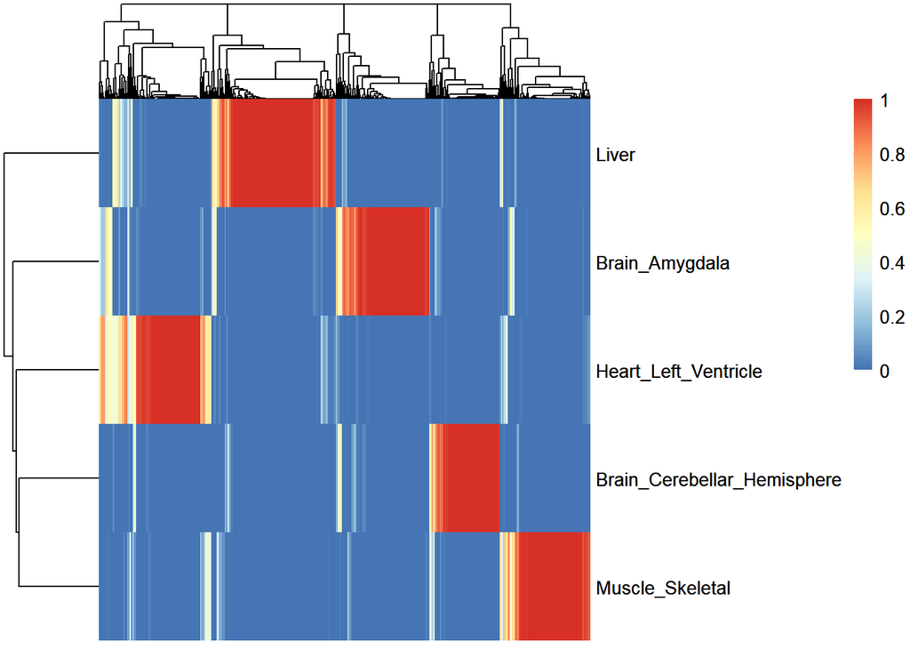

```r
plot(fit1,plotType = "TissueMem")
```

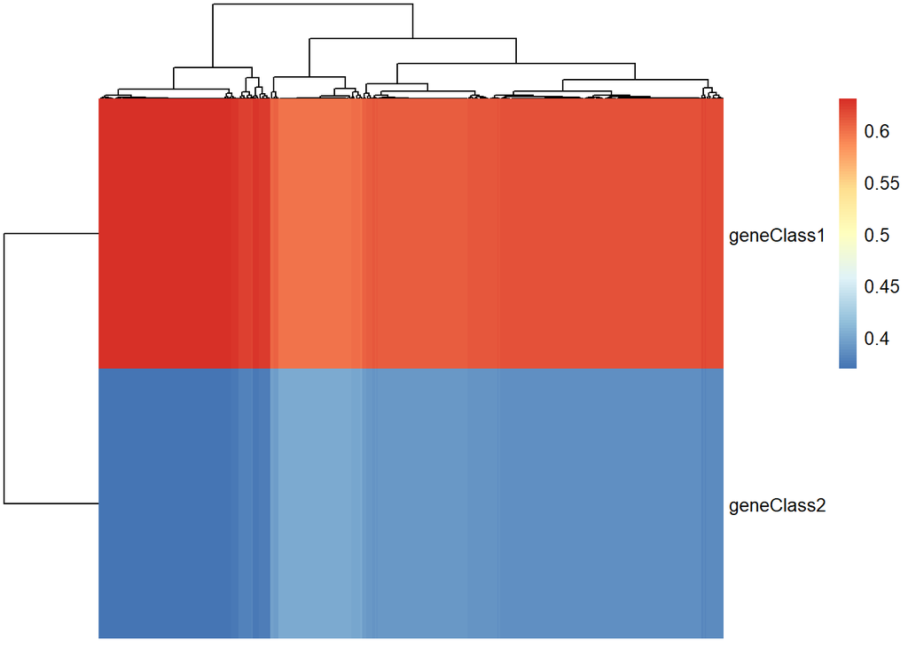

```r
plot(fit1,plotType = "ClassMem")
```

# Investigating genes

Plots can be made to observe the splicing patterns for an individual gene. The original data gets past in as an argument to `isoData` and a list of genes can be passed into `geneList`. This plots can also be subset to a subset of tissues and output to a pdf. Read the documentation for `makeGenePlots` for further information. Note: This plot is useful when the number of samples in the experimental dataset (`isoData`) is relatively small. The more samples present the harder this plot is to read. The list of tissues can also be specified through the `tissueList` parameter. Provided tissues must be a supset of the ones within the `actor` object. This can be found using the `availableTissues` function.

```
#> Making Plot for  ENSG00000122484.8
```

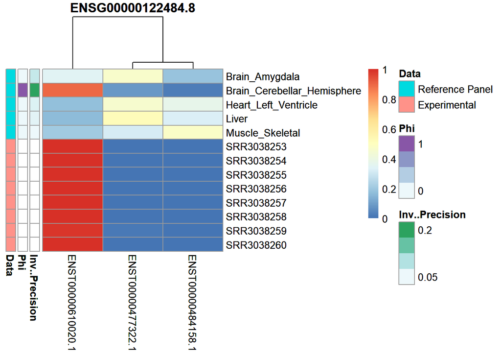

```r
makeGenePlots(actorObj=fit1,isoData=isoData,geneList="ENSG00000122484.8")
```

```r
availableTissues(actorObj=fit1)
```

```
#> [1] "Brain_Amygdala"              "Brain_Cerebellar_Hemisphere"
#> [3] "Heart_Left_Ventricle"        "Liver"
#> [5] "Muscle_Skeletal"
```

```
#> Making Plot for  ENSG00000122484.8
```

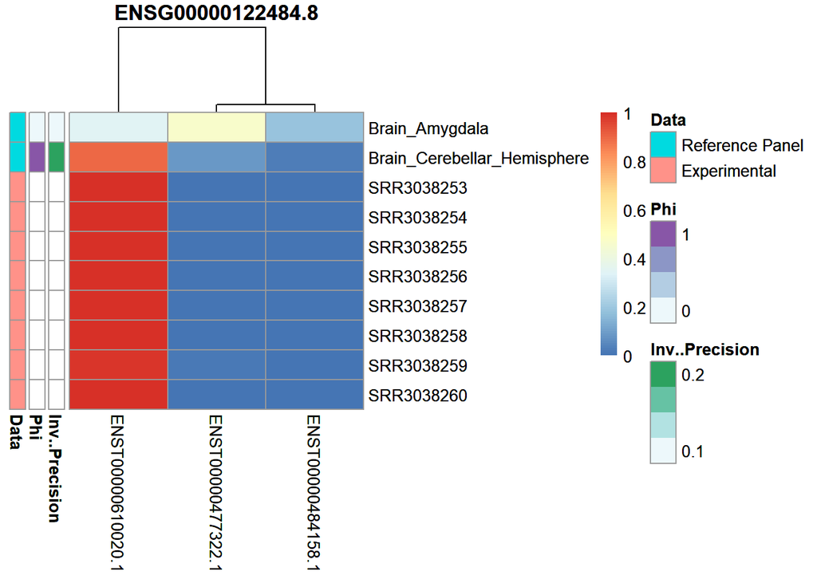

```r
makeGenePlots(actorObj=fit1,isoData=isoData,geneList="ENSG00000122484.8",tissueList = c("Brain_Amygdala","Brain_Cerebellar_Hemisphere"))
```